# A Week of Study Distractions

## What is this data about?

Over the past Month I have logged every time I was distracted while studying, recording what distracted me, where I was, and how long the distraction lasted. The goal is to find patterns in when I lose focus, so I can study more effectively.

## When during the week did my distractions happen?

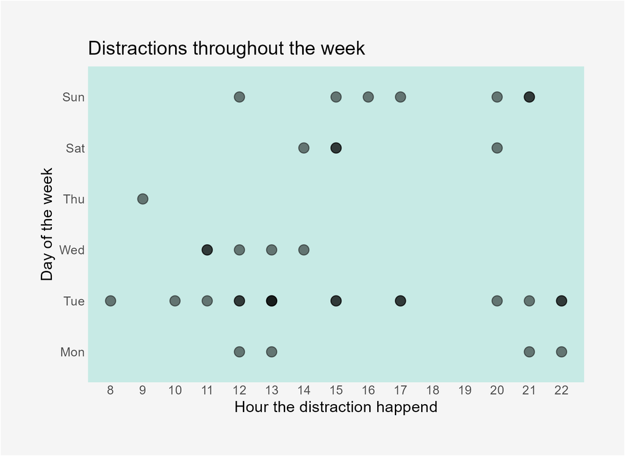

Scatter plot showing distractions by hour and day of week. Points are clustered in the afternoon and evening hours.

Distractions were not evenly spread across the days or hours. The scatter plot above shows each individual distraction event plotted by the hour it occurred and the day of the week, revealing when I was most vulnerable to losing focus.

## What was distracting me and when?

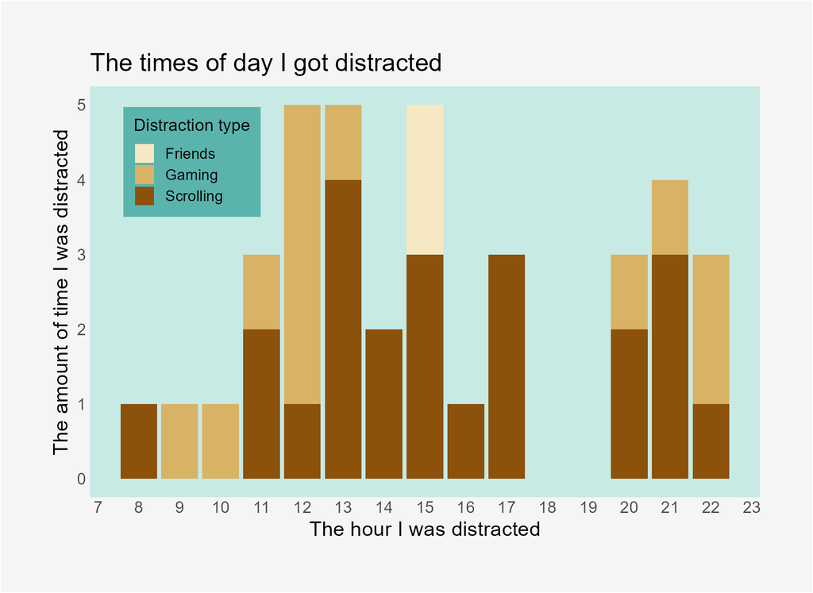

Stacked bar chart showing number of distractions per hour coloured by distraction type.

Breaking down distractions by type shows that scrolling was the most consuming cause of lost study time at most hours. While certain hours of the day show a higher concentration of other distraction types.

## Where was I studying and for how long was I distracted?

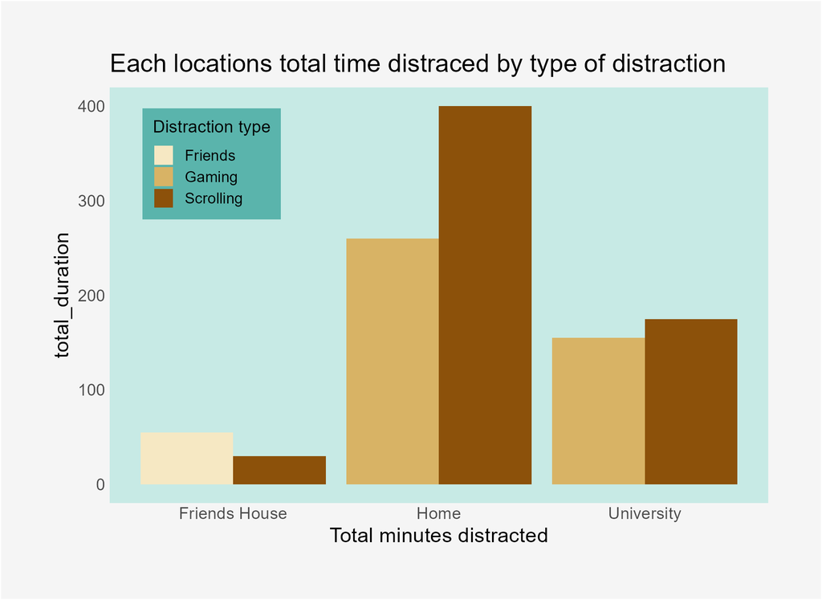

Grouped bar chart showing total minutes distracted at each study location, broken down by distraction type.

Not all study locations are equal. This chart compares the total time lost to distractions at each location, split by distraction type. Home and University show consistently longer or more frequent distractions Friends house.

## What does this tell me?

Based on a Month of logged data, there are clear patterns in when, where and what type of distractions occur. To study more effectively I should Look to have ways of reducing my access to games and social media, while my results may look like studying at a friend’s house will mean less distractions this may not be accurate as the few recorded distractions are from me not studying there much, I do however think I get distracted less at University which is hard to be reflected in the data as it doesn’t account for mow much time I acctually spend studying at each place.

[Github](https://ryan-uni-account.github.io/stats220/visual_data_story.html)